# Basic model of evolutionary rescue in discrete time with immigration and competition

Claudia Bank

2024-10-22

This noteboook is derived from the Research Practical code “Basic model of evolutionary rescue in discrete time”. Here, we introduce stochastic immigration and competition according to a logistic growth model.

## Simulating evolutionary rescue in discrete time

In this notebook, we are implementing simulations of evolutionary rescue by a single mutation in discrete time, as discussed and analyzed in the work by Orr & Unckless. The model is as follows: a haploid population starts with a given number of wild-type and mutant individuals. Because of a sudden environmental change, the wild type is unfit and declines in the new environment. The mutant is beneficial and can survive and expand in the new environment, but it starts at a low (or zero) frequency in the total population. In order to rescue the population, it has to outcompete the wild type. If the mutant is not present at time 0, it has to appear through mutation and then spread in the population before extinction occurs.

## Simulate one generation of population size change

We want to observe the numbers of wild-type and mutant individuals over time. As first step, we simulate one generation of the population. At time $t$, the population has $N_a$ wild-type individuals and $N_A$ mutant individuals. First, these reproduce. This is modeled by drawing a Poisson random variable according to the expected absolute number $N_a \cdot (1-r)$ of wild-type individuals, where $r$ is the decay rate of the wild type, and $N_A \cdot (1-r+s)$ of mutant individuals, where $s$ is the selective advantage of the mutant over the wild time. Then mutation from $a$ to $A$ occurs as a Poisson random variable according to the given mutation rate. This defines the composition of the population at time $t+1$.

## Include competition with logistic growth and migration

Steps of the life cycle:

```r
simulate_one_gen_mig_logistic <- function(N_a, N_A, carrying_capacity, decay_rate, sel_coeff, mut_rate, mig_rate_a) {
  # adult migrants arrive and are added to 'a' population
  N_a_mig <- rpois(1, mig_rate_a)
  N_a <- N_a + N_a_mig

  # determine total population size
  N_total <- N_a+N_A

  # reproduction occurs according to decay rates and selection coefficients
  offsp_a <- rpois(1, N_a * (1-decay_rate)) # independent of carrying capacity
  offsp_A <- rpois(1, min(N_A + N_A*(sel_coeff-decay_rate)*(1-N_total/carrying_capacity),N_A)) # slows down to 1 as the carrying capacity is reached

  # draw new mutants according to Poisson distribution
  mut_a_to_A <- rpois(1, offsp_a * mut_rate)

  # determine new population sizes of wild type and mutant
  N_a_new <- offsp_a - mut_a_to_A
  N_A_new <- offsp_A + mut_a_to_A

  return(c(N_a_new, N_A_new))
}
# Test the function
print(simulate_one_gen_mig_logistic(N_a=100, N_A=0, carrying_capacity=100, decay_rate=0.1, sel_coeff=0.3, mut_rate=0.1, mig_rate_a=1))
```

```
## [1] 86  6
```

### Questions

- Why do we substract `mut_a_to_A` from `N_a_new` and not from `N_A_new`?
- In the life cycle as defined above, do individuals reproduce first and then mutate, or vice versa?
- Running the test output repeatedly, why do you almost always get mutant individuals in the next generation, even though you start without any mutants?
- What does the function `c` do?

## Simulate a population trajectory

We can now track the dynamics of the population from one generation to another, but this is not enough. We want to follow the population from time 0 until it either is rescued or goes extinct. This is what the following function does.

```r
simulate_pop_mig_logistic <- function(N_init_a, N_init_A, carrying_capacity, decay_rate, sel_coeff, mut_rate, mig_rate_a, t_max) {
  # Create the vector in which to save the results
  pop_vector <- c(N_init_a, N_init_A)
  # initiate the variables
  pop_new <- c(N_init_a, N_init_A)

  # run the simulation until generation t_max
  for (i in 1:t_max+1) {
    # redefine the current population one generation later
    pop_new <- simulate_one_gen_mig_logistic(pop_new[1],pop_new[2],carrying_capacity, decay_rate, sel_coeff, mut_rate, mig_rate_a)
    # add the new population sizes to the output vector
    pop_vector <- rbind(pop_vector,pop_new)
  }

  # define the row and column names of the output vector
  rownames(pop_vector) <- (0:t_max)[1:length(pop_vector[,1])] # note that the vector has to be cut if the simulation stopped early
  colnames(pop_vector) <- c("a","A")
  # return the result
  return(pop_vector)
}


# Test the function and plot the result
# set t_max to a value to be used througout
max_gen <- 500
# create your simulation data
output <- simulate_pop_mig_logistic(100,0,100,0.1,0.2,0.001,2,max_gen)
# show the last few lines of the data table
print(tail(output))
```

```
##      a A
## 495 34 0
## 496 32 0
## 497 29 0
## 498 21 0
## 499 18 0
## 500 14 0
```

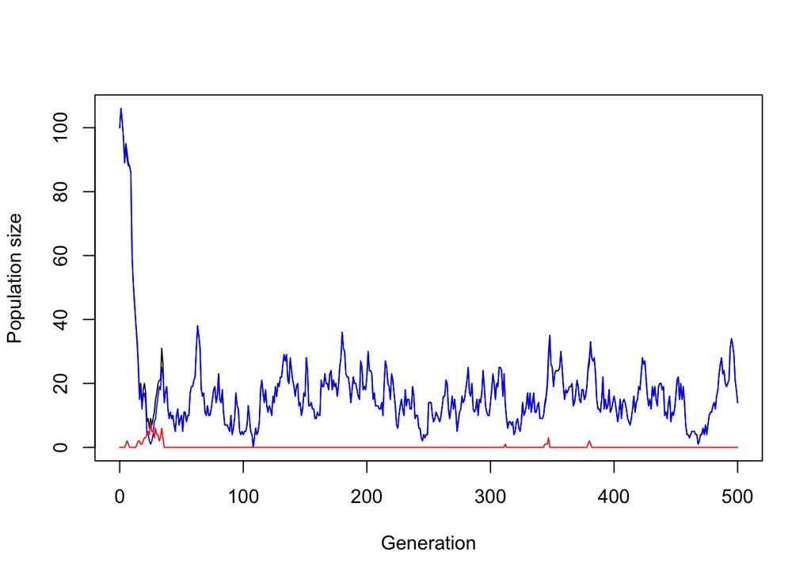

```r
# plot the output - note that the plot range and the x axis have to be adjusted based on the length of the table
# determine x axis range
x_range <- 0:(length(output[,1])-1)
# this plots the total population size
plot(x_range,output[,1]+output[,2],type='l',ylim=c(0,max(output[,1]+output[,2])),xlab = "Generation",ylab = "Population size")
# add number of wild type individuals
lines(x_range,output[,1], col="blue")
# add number of mutant individuals
lines(x_range,output[,2], col="red")
```